# GDP of India

Dasarathan Sampath

23/12/2019

## GDP of India - Historical value & analytics

GDP of a country is equal to consumption + investment + government spending + export-import. The objective of this analysis is to measure the growth of GDP against constant & current prices, compare the growth of major sectors and its contribution to total GDP.

**Note:** After the “constant 2004-05 base price” the new base price based on the year 2011-12 was released in the year 2016. - GDP of “Current price” & Constant 2004-05 base price" is based on direct GDP calculation. - GDP of “Current price GVA” & “Constant 2011-12 base price” is based on GVA calculation.

In this entire analysis, the year 2010 represents the financial year 2009-2010.

Date source for this analysis  
http://www.mospi.gov.in/

The values are in various sub-pages of the above-mentioned websites and we have manually copied the values of below said data variables into a *.CSV file. This file can be downloaded from [GDP 2004-2005 price basis](https://indiaelectiondata.in/datas/GDP_Const_2004_05.csv) & [GDP 2011-2012 price basis](https://indiaelectiondata.in/datas/GDP_Const_2011_12.csv).

Abbreviations of column variables can be found in [GDP data Variable abbreviations](https://indiaelectiondata.in/datas/GDP_abbreviations.csv)

## Definition of price basis used in this analysis

- constant 2004-05 - GDP value based on the 2004-2005 year base price
- constant 2011-12 - GDP value based on the 2011-2012 year base price
- current price - GDP value in current price
- current price GVA - GDP value in the current price calculated based on GVA method

## Analysis 1: Historical GDP values

The below chart shows GDP in “constant 2004-05”, “constant 2011-12”, current price & current price GVA.

- The year 2012 & 2013 are having both price based on “constant 2004-05” & “constant 2011-12”.
- The year 2012 GDP at “constant 2004-05 base price” is INR 52,47,530 crore, whereas the revised GDP at “constant 2011-12 base price” is INR 87,36,329 crore. The change is about 66.5%.
- Growth of GDP value at constant 2004-2005 price is varying between 4% to 9% from the year 2009.
- Growth of GDP value at constant 2011-2012 price is varying between 5% to 8% from the year 2009.
- Growth of GDP value at the current price is varying between 12% to 19% from the year 2009.
- Growth of GDP value at current price GVA is varying between 10% to 14% from the year 2009.

```r
library(reshape2)
library(ggplot2)
library(cowplot)
library(dplyr)
GDP_2004 <- read.csv("GDP_Const_2004_05.csv", stringsAsFactors =FALSE)
GDP_2011 <- read.csv("GDP_Const_2011_12.csv", stringsAsFactors =FALSE)
GDP_value_1 <- GDP_2004[,1:3]
for(i in 1:nrow(GDP_value_1)){
    if(GDP_value_1$year[i]==1951){GDP_value_1$Percent_Change[i] <- 0}
    else{GDP_value_1$Percent_Change[i] <- sprintf("%.0f %%", 100*((GDP_value_1$GDP[i] -GDP_value_1$GDP[i-1]) / GDP_value_1$GDP[i-1]))}
}
GDP_value_2 <- GDP_2011[,1:3]
for(i in 1:nrow(GDP_value_2)){
    if(GDP_value_2$year[i]==2012){GDP_value_2$Percent_Change[i] <- 0}
    else{GDP_value_2$Percent_Change[i] <- sprintf("%.0f %%", 100*((GDP_value_2$GDP[i] -GDP_value_2$GDP[i-1]) / GDP_value_2$GDP[i-1]))}
}
GDP_value <- rbind(GDP_value_1, GDP_value_2)
GDP_value$GDP <- GDP_value$GDP/1000000
GDP_value$vj <- rep(c(-1,1), length.out=nrow(GDP_value))
```

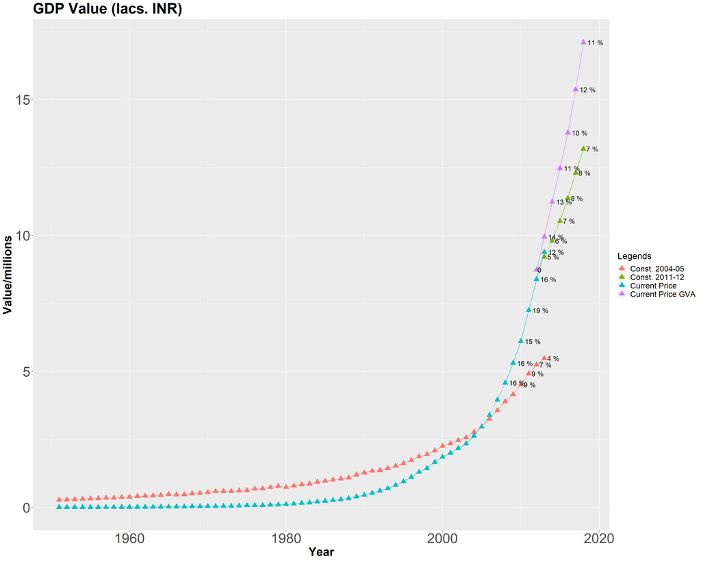

```r
plot_theme <- theme(axis.text=element_text(size=28), axis.title = element_text(size = 24,face = "bold"), plot.title = element_text(size=30, face = "bold"), legend.text = element_text(size = 16), legend.title=element_text(size=18), strip.text = element_text(size = 16))

plot_GDP <- ggplot(GDP_value, aes(GDP_value$year, GDP_value$GDP))+ geom_point(aes(color=GDP_value$Base.Price), size=4, pch=17)+ geom_line(aes(color = GDP_value$Base.Price)) +labs(x="Year", y="Value/millions", title="GDP Value (lacs. INR)", color="Legends")+ geom_text(aes(label = ifelse(GDP_value$GDP > 4.5, as.character(GDP_value$Percent_Change), '')), hjust = -0.25, vjust = 0.5, size = 5)+ plot_theme

print(plot_GDP)
```

## Analysis 2: GDP value & Trade Deficit

The below chart shows GDP, Import, Export & Trade deficit against four different price basis viz., constant 2004-05, constant 2011-12, current price & current price GVA. The percentage value on each point indicates the YoY growth. The values from the year 2001 to 2018 are plotted in this chart.

- Look at the chart “constant 2011-12” - The gap between import & export is low in 2014, 2015, 2016 & 2017. Corresponding to these years, the GDP growth is more compared to other year growth.
- Similarly on the chart “constant 2004-05” the gap between imports & export is less during 2006, 2007, 2008, 2010 & 2011. Corresponding to these years, the GDP growth is more compared to other years.

```r
GDP_TD_2004 <- select(GDP_2004, year, Base.Price, GDP, Trade.Deficit, Import, Export)
GDP_TD_2004_melt <- melt(GDP_TD_2004, c("year", "Base.Price"))
GDP_TD_2004_melt_filter <- GDP_TD_2004_melt %>% filter(year %in% 2001:2012)
GDP_TD_2004_melt_filter$value <- GDP_TD_2004_melt_filter$value/1000000
GDP_TD_2004_melt_filter$vj <- rep(c(-1,1), length.out=nrow(GDP_TD_2004_melt_filter))
for(i in 1:nrow(GDP_TD_2004_melt_filter)){
    if(GDP_TD_2004_melt_filter$year[i]==2001){GDP_TD_2004_melt_filter$Percent_Change[i] <- 0}
    else{GDP_TD_2004_melt_filter$Percent_Change[i] <- sprintf("%.0f %%", 100*((GDP_TD_2004_melt_filter$value[i] -GDP_TD_2004_melt_filter$value[i-1]) / GDP_TD_2004_melt_filter$value[i-1]))}
}
```

```r
GDP_TD_2011 <- select(GDP_2011, year, Base.Price, GDP, Trade.Deficit, Import, Export)
GDP_TD_2011_melt <- melt(GDP_TD_2011, c("year", "Base.Price"))
GDP_TD_2011_melt$value <- GDP_TD_2011_melt$value/1000000
GDP_TD_2011_melt$vj <- rep(c(-1,1), length.out=nrow(GDP_TD_2011_melt))
for(i in 1:nrow(GDP_TD_2011_melt)){
 if(GDP_TD_2011_melt$year[i]==2012){GDP_TD_2011_melt$Percent_Change[i] <- 0}
 else{GDP_TD_2011_melt$Percent_Change[i] <- sprintf("%.0f %%", 100*((GDP_TD_2011_melt$value[i] -GDP_TD_2011_melt$value[i-1]) / GDP_TD_2011_melt$value[i-1]))}
}
```

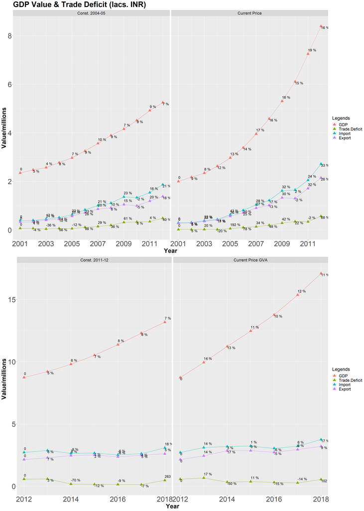

```r
GDP_TD_2004_plot <- ggplot(GDP_TD_2004_melt_filter, aes(year, value))+geom_point(aes(color=GDP_TD_2004_melt_filter$variable), size=4, pch=17)+facet_grid(.~GDP_TD_2004_melt_filter$Base.Price)+geom_line(aes(color = GDP_TD_2004_melt_filter$variable)) +labs(x="Year", y="Value/millions", title="GDP Value & Trade Deficit (lacs. INR)", color = "Legends")+ geom_text(aes(label = ifelse(GDP_TD_2004_melt_filter$value > 0, as.character(GDP_TD_2004_melt_filter$Percent_Change), '')), hjust = 0, vjust = GDP_TD_2004_melt_filter$vj, size = 5)+ plot_theme + scale_x_continuous(breaks = round(seq(min(GDP_TD_2004_melt_filter$year), max(GDP_TD_2004_melt_filter$year), by = 2),1))

GDP_TD_2011_plot <- ggplot(GDP_TD_2011_melt, aes(year, value))+geom_point(aes(color=GDP_TD_2011_melt$variable), size=4, pch=17)+facet_grid(.~GDP_TD_2011_melt$Base.Price)+geom_line(aes(color = GDP_TD_2011_melt$variable)) +labs(x="Year", y="Value/millions", color = "Legends")+ geom_text(aes(label = ifelse(GDP_TD_2011_melt$value > 0, as.character(GDP_TD_2011_melt$Percent_Change), '')), hjust = 0, vjust = GDP_TD_2011_melt$vj, size = 5)+ plot_theme

plot_grid(GDP_TD_2004_plot, GDP_TD_2011_plot, nrow = 2)
```

## Analysis 3: GDP of Agricultural products and its Contribution to total GDP

The below chart shows the total GDP & GDP of agricultural products. The percentage value given over each point of “GDP_AGRI” & “GVA_AGRI” is the percentage contribution of agricultural products to the overall GDP. From 2011 the GDP value is calculated based on the GVA basis. The values from the year 2001 to 2018 are plotted in this chart.

```r
GDP_Agri_2004 <- select(GDP_2004, "year", "Base.Price", "GDP", "GDP_AGRI")
GDP_Agri_2004_filter <- GDP_Agri_2004 %>% filter(year %in% 2001:2012)
for(i in 1:nrow(GDP_Agri_2004_filter)){
 if(GDP_Agri_2004_filter$year[i]==2001){GDP_Agri_2004_filter$Percent_Change[i] <- 0}
 else{GDP_Agri_2004_filter$Percent_Change[i] <- round(100*GDP_Agri_2004_filter$GDP_AGRI[i]/GDP_Agri_2004_filter$GDP[i], digits = 2)}
}
GDP_Agri_2004_melt <- melt(GDP_Agri_2004_filter, c("year", "Base.Price", "Percent_Change"))
GDP_Agri_2004_melt$value <- GDP_Agri_2004_melt$value/1000000

GDP_Agri_2011 <- select(GDP_2011, "year", "Base.Price", "GDP", "GVA_AGRI")
#GDP_Agri_2011_filter <- GDP_Agri_2011 %>% filter(year %in% 2001:2012)
for(i in 1:nrow(GDP_Agri_2011)){
 if(GDP_Agri_2011$year[i]==2012){GDP_Agri_2011$Percent_Change[i] <- 0}
 else{GDP_Agri_2011$Percent_Change[i] <- round(100*GDP_Agri_2011$GVA_AGRI[i]/GDP_Agri_2011$GDP[i], digits = 2)}
}
GDP_Agri_2011_melt <- melt(GDP_Agri_2011, c("year", "Base.Price", "Percent_Change"))
GDP_Agri_2011_melt$value <- GDP_Agri_2011_melt$value/1000000
```

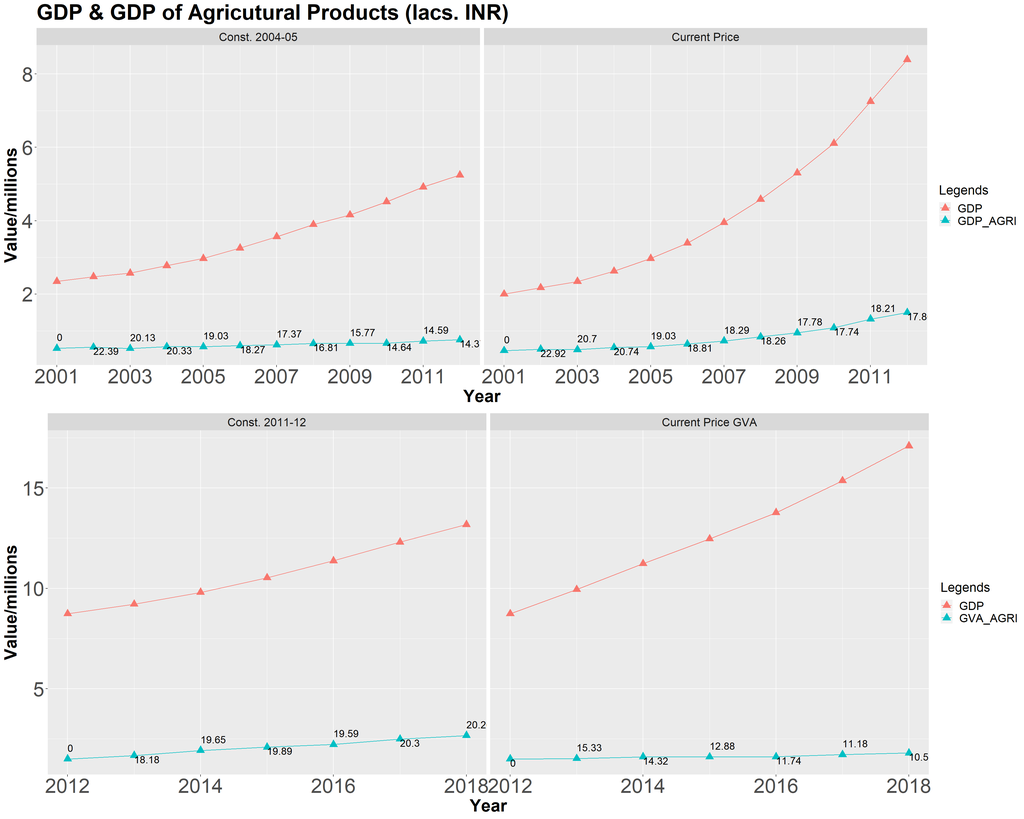

```r
GDP_Agri_2004_melt$vj <- rep(c(-1,1), length.out=nrow(GDP_Agri_2004_melt))
GDP_Agri_2011_melt$vj <- rep(c(-1,1), length.out=nrow(GDP_Agri_2011_melt))

GDP_Agri_plot_2004 <- ggplot(GDP_Agri_2004_melt, aes(year, value))+ geom_point(aes(color=variable), size=4, pch=17)+ facet_grid(.~Base.Price)+ geom_line(aes(color = GDP_Agri_2004_melt$variable))+ geom_text(aes(label= ifelse(GDP_Agri_2004_melt$variable == "GDP_AGRI", GDP_Agri_2004_melt$Percent_Change, '')),hjust = 0, vjust = GDP_Agri_2004_melt$vj, size = 5)+ labs(x="Year", y="Value/millions", title="GDP & GDP of Agricutural Products (lacs. INR)", color = "Legends") + plot_theme + scale_x_continuous(breaks = round(seq(min(GDP_Agri_2004_melt$year), max(GDP_Agri_2004_melt$year), by = 2),1))

GDP_Agri_plot_2011 <- ggplot(GDP_Agri_2011_melt, aes(year, value))+ geom_point(aes(color=variable), size=4, pch=17)+ facet_grid(.~Base.Price)+ geom_line(aes(color = GDP_Agri_2011_melt$variable))+ geom_text(aes(label= ifelse(GDP_Agri_2011_melt$variable == "GVA_AGRI", GDP_Agri_2011_melt$Percent_Change, '')),hjust = 0, vjust = GDP_Agri_2011_melt$vj, size = 5)+ labs(x="Year", y="Value/millions", color = "Legends") + plot_theme + scale_x_continuous(breaks = round(seq(min(GDP_Agri_2011_melt$year), max(GDP_Agri_2011_melt$year), by = 2),1))

plot_grid(GDP_Agri_plot_2004, GDP_Agri_plot_2011, nrow = 2)
```